# KOICA 해외봉사단 파견현황

3주차

Author

최요한

Published

June 25, 2026

**Note**

🛠️ 핵심 패키지

#R 데이터분석의 핵심 패키지 “tidyverse”

```r
library(tidyverse)            # 라이브러리 로드
```

```r
# install.packages("showtext")        # 표 생성 패키지
library(showtext)                     # 라이브러리 로드
showtext_auto()                       # 한글을 표시
```

# 1 자료 출처

🔗 출처: [공공데이터포탈](https://www.data.go.kr/data/15051101/fileData.do)

[figure not shown]

> 데이터 샘플

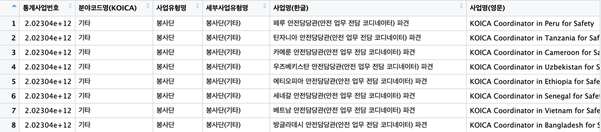

KOICA 해외봉사단 파견현황

# 2 csv 파일 불러오기

## 2.1 변수에 저장하기

> 변수명: koica_wfk_20260331

```r
read_csv(
  "../../99.files/koica_wfk_20260331.csv"
  ) ->  koica_wfk_20260331

print(koica_wfk_20260331)
```

```
# A tibble: 196 × 6
    연도 단원형태   국가명 파견직종         파견분야        인원
   <dbl> <chr>      <chr>  <chr>            <chr>          <dbl>
 1  2026 일반봉사단 가나   유아교육         교육               2
 2  2026 일반봉사단 가나   전기/전력        기술환경에너지     1
 3  2026 일반봉사단 가나   체육교육(일반)   교육               1
 4  2026 일반봉사단 가나   컴퓨터교육(일반) 교육               1
 5  2026 일반봉사단 가나   한국어교육(일반) 교육               1
 6  2026 일반봉사단 네팔   관광             공공행정           1
 7  2026 일반봉사단 네팔   사회복지         공공행정           1
 8  2026 일반봉사단 네팔   유아교육         교육               1
 9  2026 일반봉사단 네팔   임상병리         보건의료           1
10  2026 일반봉사단 네팔   자동차           기술환경에너지     1
# ℹ 186 more rows
```

# 3 데이터 톺아보기

## 3.1 데이터셋 구조보기

#### glimpse()

데이터 셋의 전체 크기, 변수의 자료형을 보여주고, 대략 어떤 값들로 채워져 있는지 정돈된 형태로 출력

> 데이터셋의 물리적 구조를 스냅샷으로 제공

```r
koica_wfk_20260331 |>
  glimpse()
```

```
Rows: 196
Columns: 6
$ 연도     <dbl> 2026, 2026, 2026, 2026, 2026, 2026, 2026, 2026, 2026, 2026, 2…
$ 단원형태 <chr> "일반봉사단", "일반봉사단", "일반봉사단", "일반봉사단", "일반봉사단", "일반봉사단", "일반봉사단"…
$ 국가명   <chr> "가나", "가나", "가나", "가나", "가나", "네팔", "네팔", "네팔", "네팔", "네팔", "…
$ 파견직종 <chr> "유아교육", "전기/전력", "체육교육(일반)", "컴퓨터교육(일반)", "한국어교육(일반)", "관광", …
$ 파견분야 <chr> "교육", "기술환경에너지", "교육", "교육", "교육", "공공행정", "공공행정", "교육", "보건의…
$ 인원     <dbl> 2, 1, 1, 1, 1, 1, 1, 1, 1, 1, 2, 1, 2, 2, 2, 1, 1, 1, 2, 1, 1…
```

#### summary()

데이터셋의 평균, 중앙값, 이상치(Outlier), NA(결측치) 등을 요약해서 출력

> 데이터셋의 기초 통계량을 리포트

```r
koica_wfk_20260331 |>
  summary()
```

```
      연도        단원형태            국가명            파견직종
 Min.   :2026   Length:196         Length:196         Length:196
 1st Qu.:2026   Class :character   Class :character   Class :character
 Median :2026   Mode  :character   Mode  :character   Mode  :character
 Mean   :2026
 3rd Qu.:2026
 Max.   :2026
   파견분야              인원
 Length:196         Min.   : 1.000
 Class :character   1st Qu.: 1.000
 Mode  :character   Median : 1.000
                    Mean   : 1.801
                    3rd Qu.: 2.000
                    Max.   :16.000
```

> 문자형, 범주형 등은 제외하고 연속형 데이터 기초 통계량만 보는 법

```r
koica_wfk_20260331 |>
  select(where(is.double)) |>
  summary()
```

```
      연도           인원
 Min.   :2026   Min.   : 1.000
 1st Qu.:2026   1st Qu.: 1.000
 Median :2026   Median : 1.000
 Mean   :2026   Mean   : 1.801
 3rd Qu.:2026   3rd Qu.: 2.000
 Max.   :2026   Max.   :16.000
```

#### 연속형은 제외하고 문자형, 범주형 등의 기초 통계량만 보는 법

```r
koica_wfk_20260331 |>
  select(-where(is.double)) |>
  summary()
```

```
   단원형태            국가명            파견직종           파견분야
 Length:196         Length:196         Length:196         Length:196
 Class :character   Class :character   Class :character   Class :character
 Mode  :character   Mode  :character   Mode  :character   Mode  :character
```

### 3.1.1 변수명 확인하기

#### colnames()

```r
koica_wfk_20260331 |>
  colnames()
```

```
[1] "연도"     "단원형태" "국가명"   "파견직종" "파견분야" "인원"
```

### 3.1.2 (Tip) 고유값 살펴보기

데이터셋 각 변수들의 고유한 값들을 한번에 조회합니다.

데이터들의 구성 요소들을 가늠할수 있습니다.

#### 📮 sapply(n_distinct)

```r
koica_wfk_20260331 |>
  sapply(n_distinct)
```

```
    연도 단원형태   국가명 파견직종 파견분야     인원
       1        1       33       45        5       11
```

`enframe() 함수와 함께 사용하면 tibble 형식으로 보기 좋게 출력합니다`

#### 📮 enframe()

```r
koica_wfk_20260331 |>
  sapply(n_distinct) |>
  enframe(
    name = 'column',
    value = 'value')
```

```
# A tibble: 6 × 2
  column   value
  <chr>    <int>
1 연도         1
2 단원형태     1
3 국가명      33
4 파견직종    45
5 파견분야     5
6 인원        11
```

### 3.1.3 데이터 체크

```r
koica_wfk_20260331 |>
  count(국가명)
```

```
# A tibble: 33 × 2
   국가명             n
   <chr>          <int>
 1 가나               5
 2 네팔               8
 3 도미니카공화국     4
 4 동티모르          12
 5 라오스             9
 6 르완다             8
 7 모로코            11
 8 몽골               9
 9 방글라데시         2
10 베트남             9
# ℹ 23 more rows
```

## 3.2 Raw data 훓어보기

### 3.2.1 print(n = Inf)

> 데이터를 생략하지 말고 화면에 모두 출력합니다.

```r
# 해당 조건을 충족하는 모든 데이터를 출력 (생략없음)
koica_wfk_20260331 |>
  filter(파견분야 == '교육') |>
  print(n = Inf)
```

```
# A tibble: 110 × 6
     연도 단원형태   국가명         파견직종              파견분야  인원
    <dbl> <chr>      <chr>          <chr>                 <chr>    <dbl>
  1  2026 일반봉사단 가나           유아교육              교육         2
  2  2026 일반봉사단 가나           체육교육(일반)        교육         1
  3  2026 일반봉사단 가나           컴퓨터교육(일반)      교육         1
  4  2026 일반봉사단 가나           한국어교육(일반)      교육         1
  5  2026 일반봉사단 네팔           유아교육              교육         1
  6  2026 일반봉사단 네팔           초등교육              교육         2
  7  2026 일반봉사단 네팔           특수교육              교육         1
  8  2026 일반봉사단 네팔           한국어교육(일반)      교육         2
  9  2026 일반봉사단 도미니카공화국 미술교육              교육         2
 10  2026 일반봉사단 도미니카공화국 음악교육              교육         1
 11  2026 일반봉사단 도미니카공화국 특수교육              교육         1
 12  2026 일반봉사단 동티모르       사서                  교육         1
```

[output cut: 98 more lines]

```r
# 해당 조건을 충족하는 모든 데이터를 위에서부터 25개만 출력
koica_wfk_20260331 |>
  filter(파견분야 == '교육') |>
  print(n = 25)
```

```
# A tibble: 110 × 6
    연도 단원형태   국가명         파견직종              파견분야  인원
   <dbl> <chr>      <chr>          <chr>                 <chr>    <dbl>
 1  2026 일반봉사단 가나           유아교육              교육         2
 2  2026 일반봉사단 가나           체육교육(일반)        교육         1
 3  2026 일반봉사단 가나           컴퓨터교육(일반)      교육         1
 4  2026 일반봉사단 가나           한국어교육(일반)      교육         1
 5  2026 일반봉사단 네팔           유아교육              교육         1
 6  2026 일반봉사단 네팔           초등교육              교육         2
 7  2026 일반봉사단 네팔           특수교육              교육         1
 8  2026 일반봉사단 네팔           한국어교육(일반)      교육         2
 9  2026 일반봉사단 도미니카공화국 미술교육              교육         2
10  2026 일반봉사단 도미니카공화국 음악교육              교육         1
11  2026 일반봉사단 도미니카공화국 특수교육              교육         1
12  2026 일반봉사단 동티모르       사서                  교육         1
13  2026 일반봉사단 동티모르       유아교육              교육         1
14  2026 일반봉사단 동티모르       청소년개발            교육         1
15  2026 일반봉사단 동티모르       컴퓨터교육(일반)      교육         2
16  2026 일반봉사단 동티모르       한국어교육(EPS-TOPIK) 교육         1
17  2026 일반봉사단 동티모르       한국어교육(일반)      교육         5
18  2026 일반봉사단 라오스         미술교육              교육         1
19  2026 일반봉사단 라오스         미용교육              교육         1
20  2026 일반봉사단 라오스         음악교육              교육         1
21  2026 일반봉사단 라오스         체육교육(일반)        교육         2
22  2026 일반봉사단 라오스         체육교육(태권도)      교육         1
23  2026 일반봉사단 라오스         컴퓨터교육(일반)      교육         2
24  2026 일반봉사단 라오스         한국어교육(심화)      교육         4
25  2026 일반봉사단 르완다         유아교육              교육         1
# ℹ 85 more rows
```

#### head()

> 앞에 6줄만 출력

```r
koica_wfk_20260331 |>
  head()
```

```
# A tibble: 6 × 6
   연도 단원형태   국가명 파견직종         파견분야        인원
  <dbl> <chr>      <chr>  <chr>            <chr>          <dbl>
1  2026 일반봉사단 가나   유아교육         교육               2
2  2026 일반봉사단 가나   전기/전력        기술환경에너지     1
3  2026 일반봉사단 가나   체육교육(일반)   교육               1
4  2026 일반봉사단 가나   컴퓨터교육(일반) 교육               1
5  2026 일반봉사단 가나   한국어교육(일반) 교육               1
6  2026 일반봉사단 네팔   관광             공공행정           1
```

#### tail()

> 뒤에 6줄만 출력

```r
koica_wfk_20260331 |>
  tail()
```

```
# A tibble: 6 × 6
   연도 단원형태   국가명 파견직종         파견분야  인원
  <dbl> <chr>      <chr>  <chr>            <chr>    <dbl>
1  2026 일반봉사단 피지   치위생           보건의료     2
2  2026 일반봉사단 피지   컴퓨터교육(일반) 교육         1
3  2026 일반봉사단 필리핀 간호             보건의료     1
4  2026 일반봉사단 필리핀 과학교육         교육         1
5  2026 일반봉사단 필리핀 농업             농림수산     1
6  2026 일반봉사단 필리핀 한국어교육(일반) 교육         1
```

### 3.2.2 (Tip) 그룹별로 훓어보기

#### 📮 split()

지정한 변수의 고유값별로 데이터를 그룹단위로 출력합니다.

```r
koica_wfk_20260331 |>
  split(koica_wfk_20260331$파견분야)
```

[output not shown]

# 4 EDA

## 4.1 탐색적 데이터 분석

### 4.1.1 group_by() + geom_bar()

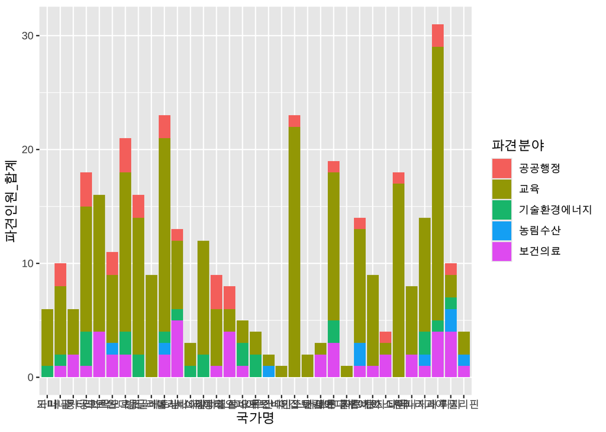

```r
koica_wfk_20260331 |>
  group_by(국가명, 파견분야) |>
  reframe(파견인원_합계 = sum(인원)) |>
  ggplot(aes(x = 국가명, y = 파견인원_합계, fill = 파견분야)) +
  geom_bar(stat = 'identity')
```

```r
koica_wfk_20260331 |>
  group_by(국가명, 파견분야) |>
  reframe(파견인원_합계 = sum(인원)) |>
  ggplot(aes(x = 국가명, y = 파견인원_합계, fill = 파견분야)) +
  geom_bar(stat = 'identity') +
  coord_flip()
```

[output not shown]

### 4.1.2 group_by() + geom_tile()

> 국가별 파견분야별 파견인원을 히트맵을 그립니다.

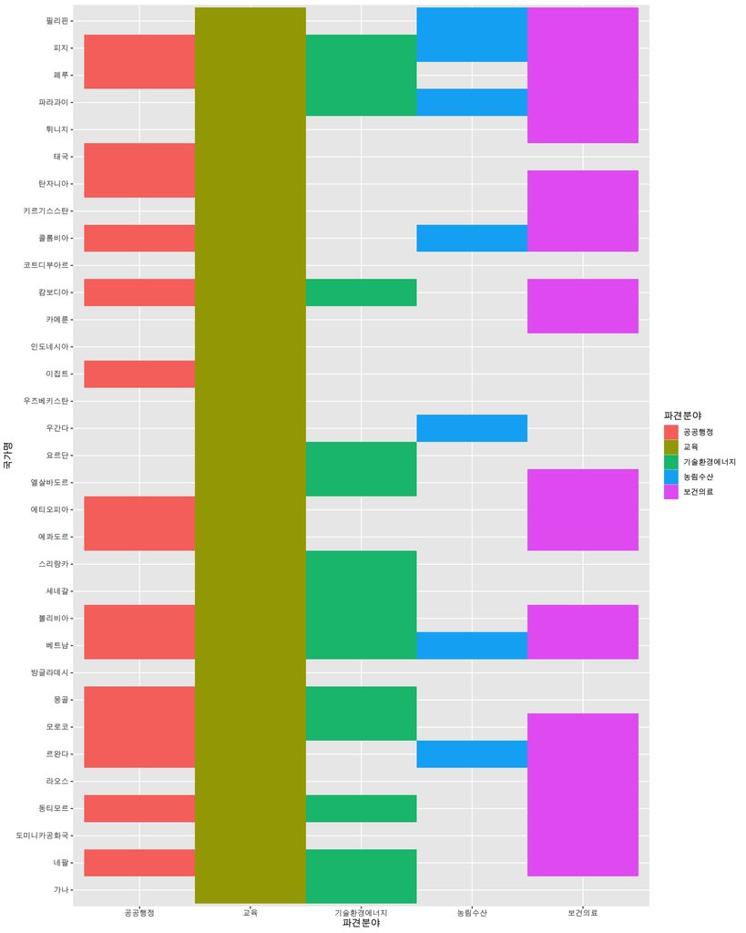

```r
koica_wfk_20260331 |>
  group_by(국가명, 파견분야) |>
  reframe(파견인원_합계 = sum(인원)) |>
  ggplot(aes(x = 파견분야, y = 국가명, fill = 파견분야)) +
  geom_tile()
```

### 4.1.3 geom_text() + theme_minimal()

> 데이터를 선별하고, 히트맵을 예쁘게 꾸며줍니다.

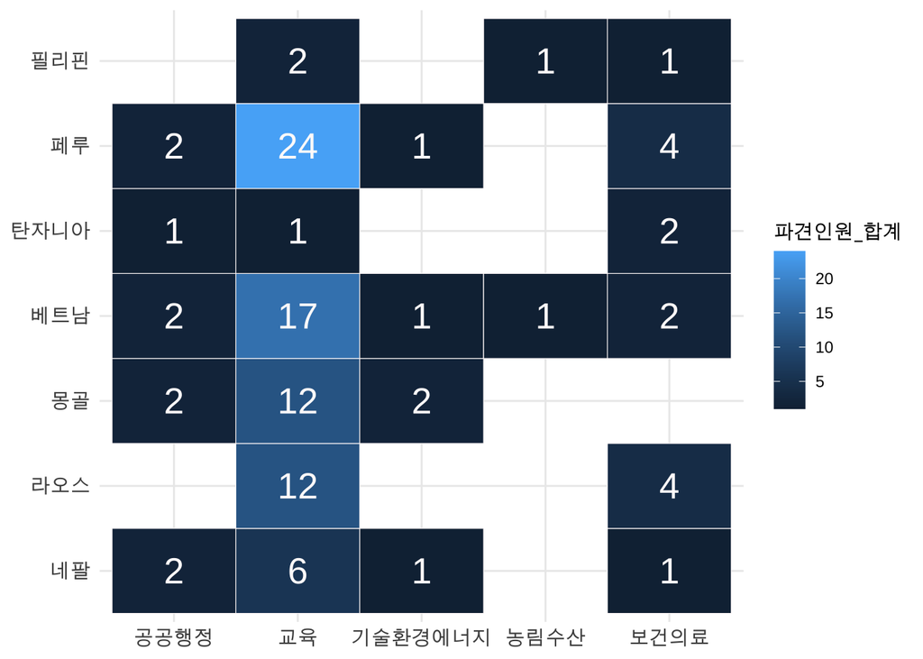

```r
koica_wfk_20260331 |>
  group_by(국가명, 파견분야) |>
  reframe(파견인원_합계 = sum(인원)) |>
  filter(국가명 %in% c("페루", "라오스", "몽골","네팔",
                    "탄자니아", "베트남", "필리핀")) |>
  ggplot(aes(x = 파견분야, y = 국가명, fill = 파견인원_합계)) +
  geom_tile(color = 'snow') +
  geom_text(aes(label = 파견인원_합계), color = 'snow', size = 7) +
  theme_minimal() +
  theme(axis.title = element_blank(),
        axis.text = element_text(size = 11))
```

### 4.1.4 히스토그램

> 파견인원 분포

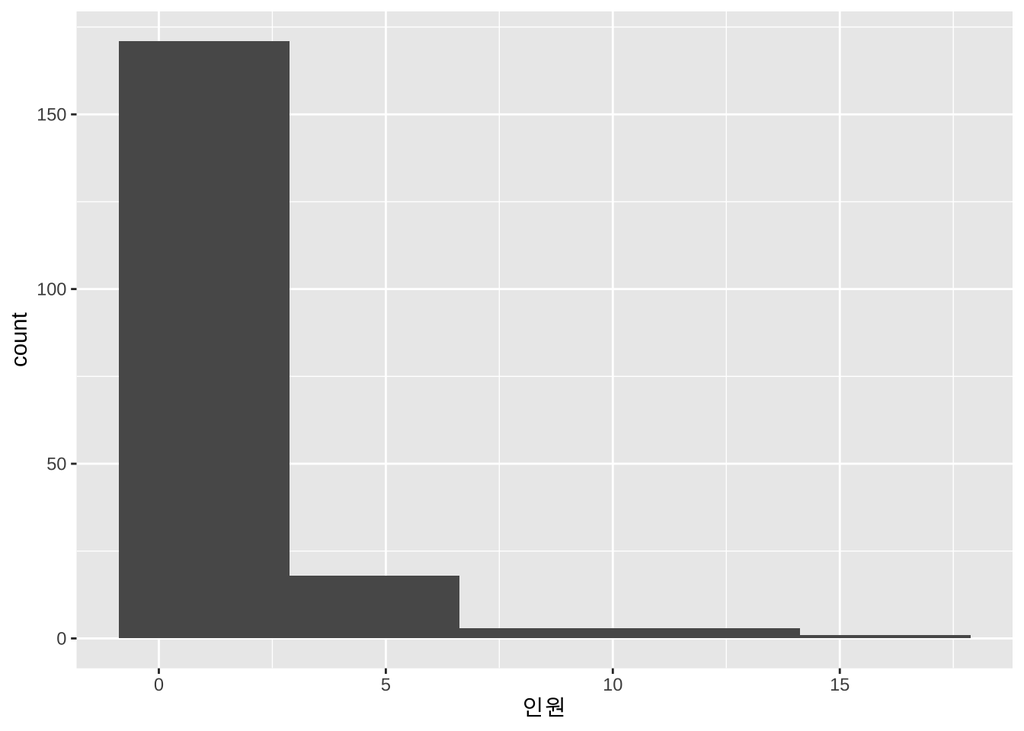

```r
koica_wfk_20260331 |>
  ggplot(aes(x = 인원)) +
  geom_histogram(bins = 5)
```

#### geom_histogram(binwidth = 1)

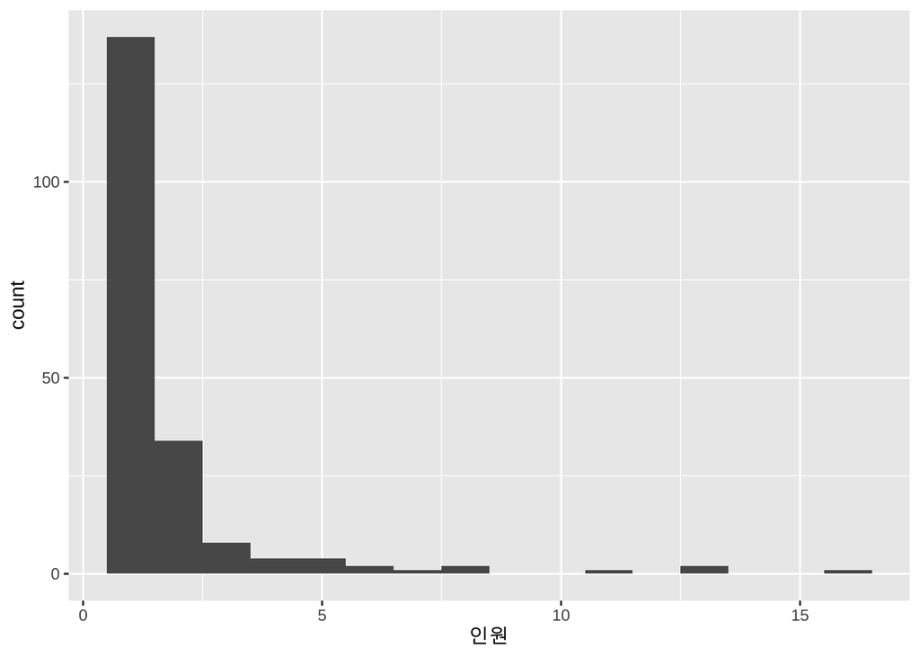

```r
koica_wfk_20260331 |>
  ggplot(aes(x = 인원)) +
  geom_histogram(binwidth = 1)
```

### 4.1.6 이상치 탐색

geom_boxplot()

> 파견 분야에서 이상치

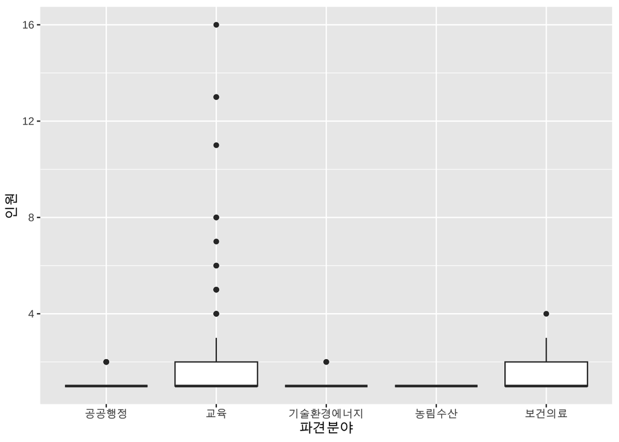

```r
koica_wfk_20260331 |>
  ggplot(aes(x = 파견분야, y = 인원)) +
  geom_boxplot()
```

# 5 데이터 전처리

## 5.1 select

```r
koica_wfk_20260331 |>
  select("국가명","파견직종", "파견분야", "인원")
```

```
# A tibble: 196 × 4
   국가명 파견직종         파견분야        인원
   <chr>  <chr>            <chr>          <dbl>
 1 가나   유아교육         교육               2
 2 가나   전기/전력        기술환경에너지     1
 3 가나   체육교육(일반)   교육               1
 4 가나   컴퓨터교육(일반) 교육               1
 5 가나   한국어교육(일반) 교육               1
 6 네팔   관광             공공행정           1
 7 네팔   사회복지         공공행정           1
 8 네팔   유아교육         교육               1
 9 네팔   임상병리         보건의료           1
10 네팔   자동차           기술환경에너지     1
# ℹ 186 more rows
```

## 5.2 할당 연산자

할당연산자를 통해 데이터를 복사할수 있고 할당연산자는 양방향으로 동작합니다.

> ->

> <-

```r
#1안과 2안은 동일한 결과를 출력
# 1안
koica_wfk_20260331 |>
  select("국가명","파견직종", "파견분야", "인원") -> koica_1_select

# 2안
koica_1_select <- koica_wfk_20260331 |>
  select("국가명","파견직종", "파견분야", "인원")
```

## 5.3 arrange()

특정 기준에 맞춰 오름차순, 내림차순합니다

```r
# 인원순서대로 오름차순
koica_1_select |>
      arrange(인원)
```

```
# A tibble: 196 × 4
   국가명 파견직종         파견분야        인원
   <chr>  <chr>            <chr>          <dbl>
 1 가나   전기/전력        기술환경에너지     1
 2 가나   체육교육(일반)   교육               1
 3 가나   컴퓨터교육(일반) 교육               1
 4 가나   한국어교육(일반) 교육               1
 5 네팔   관광             공공행정           1
 6 네팔   사회복지         공공행정           1
 7 네팔   유아교육         교육               1
 8 네팔   임상병리         보건의료           1
 9 네팔   자동차           기술환경에너지     1
10 네팔   특수교육         교육               1
# ℹ 186 more rows
```

```r
# 인원순서대로 내림차순
koica_1_select |>
      arrange(desc(인원))
```

```
# A tibble: 196 × 4
   국가명       파견직종         파견분야  인원
   <chr>        <chr>            <chr>    <dbl>
 1 태국         한국어교육(일반) 교육        16
 2 베트남       한국어교육(일반) 교육        13
 3 이집트       한국어교육(일반) 교육        13
 4 페루         한국어교육(일반) 교육        11
 5 모로코       한국어교육(일반) 교육         8
 6 몽골         한국어교육(일반) 교육         8
 7 캄보디아     한국어교육(일반) 교육         7
 8 방글라데시   한국어교육(일반) 교육         6
 9 키르기스스탄 한국어교육(일반) 교육         6
10 동티모르     한국어교육(일반) 교육         5
# ℹ 186 more rows
```

## 5.4 filter()

#### filter는 조건에 맞춰 데이터를 조회합니다

### 5.4.1 같다

> ==

`국가명이 페루와 같은 것을 출력합니다`

```r
koica_1_select |>
  filter(국가명 == "페루")
```

```
# A tibble: 15 × 4
   국가명 파견직종         파견분야        인원
   <chr>  <chr>            <chr>          <dbl>
 1 페루   간호             보건의료           1
 2 페루   물리치료         보건의료           1
 3 페루   미술교육         교육               2
 4 페루   보건의료 일반    보건의료           1
 5 페루   사회복지         공공행정           2
 6 페루   수학교육         교육               2
 7 페루   영양관리         보건의료           1
 8 페루   유아교육         교육               1
 9 페루   음악교육         교육               3
10 페루   체육교육(태권도) 교육               1
11 페루   초등교육         교육               1
12 페루   컴퓨터교육(일반) 교육               2
13 페루   특수교육         교육               1
14 페루   한국어교육(일반) 교육              11
15 페루   환경             기술환경에너지     1
```

### 5.4.2 다르다

> !=

`국가명이 페루와 다른 것을 출력합니다`

```r
koica_1_select |>
  filter(국가명 != "페루")
```

```
# A tibble: 181 × 4
   국가명 파견직종         파견분야        인원
   <chr>  <chr>            <chr>          <dbl>
 1 가나   유아교육         교육               2
 2 가나   전기/전력        기술환경에너지     1
 3 가나   체육교육(일반)   교육               1
 4 가나   컴퓨터교육(일반) 교육               1
 5 가나   한국어교육(일반) 교육               1
 6 네팔   관광             공공행정           1
 7 네팔   사회복지         공공행정           1
 8 네팔   유아교육         교육               1
 9 네팔   임상병리         보건의료           1
10 네팔   자동차           기술환경에너지     1
# ℹ 171 more rows
```

### 5.4.3 포함한다

> %in%

`국가명이 '페루'이거나, '라오스'이거나, '몽골'인 것을 출력합니다`

```r
koica_1_select |>
  filter(국가명 %in% c("페루", "라오스", "몽골"))
```

```
# A tibble: 33 × 4
   국가명 파견직종         파견분야  인원
   <chr>  <chr>            <chr>    <dbl>
 1 라오스 간호             보건의료     3
 2 라오스 미술교육         교육         1
 3 라오스 미용교육         교육         1
 4 라오스 방사선           보건의료     1
 5 라오스 음악교육         교육         1
 6 라오스 체육교육(일반)   교육         2
 7 라오스 체육교육(태권도) 교육         1
 8 라오스 컴퓨터교육(일반) 교육         2
 9 라오스 한국어교육(심화) 교육         4
10 몽골   디지털미디어     공공행정     1
# ℹ 23 more rows
```

### 5.4.4 포함하지 않는다

> !변수명 %in% c()

`국가명이 '페루'도 아니고 '라오스'도 아니고 '몽골'도 아닌 것을 출력합니다`

```r
koica_1_select |>
  filter(!국가명 %in% c("페루", "라오스", "몽골"))
```

```
# A tibble: 163 × 4
   국가명 파견직종         파견분야        인원
   <chr>  <chr>            <chr>          <dbl>
 1 가나   유아교육         교육               2
 2 가나   전기/전력        기술환경에너지     1
 3 가나   체육교육(일반)   교육               1
 4 가나   컴퓨터교육(일반) 교육               1
 5 가나   한국어교육(일반) 교육               1
 6 네팔   관광             공공행정           1
 7 네팔   사회복지         공공행정           1
 8 네팔   유아교육         교육               1
 9 네팔   임상병리         보건의료           1
10 네팔   자동차           기술환경에너지     1
# ℹ 153 more rows
```

### 5.4.5 크다, 작다, 크거나 같다, 작거나 같다

> >, <, >=, <=

```r
koica_1_select |>
  filter(인원 > 10)
```

```
# A tibble: 4 × 4
  국가명 파견직종         파견분야  인원
  <chr>  <chr>            <chr>    <dbl>
1 베트남 한국어교육(일반) 교육        13
2 이집트 한국어교육(일반) 교육        13
3 태국   한국어교육(일반) 교육        16
4 페루   한국어교육(일반) 교육        11
```

```r
koica_1_select |>
  filter(인원 >= 13)
```

```
# A tibble: 3 × 4
  국가명 파견직종         파견분야  인원
  <chr>  <chr>            <chr>    <dbl>
1 베트남 한국어교육(일반) 교육        13
2 이집트 한국어교육(일반) 교육        13
3 태국   한국어교육(일반) 교육        16
```

```r
koica_1_select |>
  filter(인원 < 2)
```

```
# A tibble: 137 × 4
   국가명 파견직종         파견분야        인원
   <chr>  <chr>            <chr>          <dbl>
 1 가나   전기/전력        기술환경에너지     1
 2 가나   체육교육(일반)   교육               1
 3 가나   컴퓨터교육(일반) 교육               1
 4 가나   한국어교육(일반) 교육               1
 5 네팔   관광             공공행정           1
 6 네팔   사회복지         공공행정           1
 7 네팔   유아교육         교육               1
 8 네팔   임상병리         보건의료           1
 9 네팔   자동차           기술환경에너지     1
10 네팔   특수교육         교육               1
# ℹ 127 more rows
```

```r
koica_1_select |>
  filter(인원 <= 2 )
```

```
# A tibble: 171 × 4
   국가명 파견직종         파견분야        인원
   <chr>  <chr>            <chr>          <dbl>
 1 가나   유아교육         교육               2
 2 가나   전기/전력        기술환경에너지     1
 3 가나   체육교육(일반)   교육               1
 4 가나   컴퓨터교육(일반) 교육               1
 5 가나   한국어교육(일반) 교육               1
 6 네팔   관광             공공행정           1
 7 네팔   사회복지         공공행정           1
 8 네팔   유아교육         교육               1
 9 네팔   임상병리         보건의료           1
10 네팔   자동차           기술환경에너지     1
# ℹ 161 more rows
```

### 5.4.6 제시된 조건을 모두 충족하는 경우 (and 조건)

> &

> ’앰퍼샌드’라고 읽습니다

```r
koica_1_select |>
  filter(인원 < 2 & 파견직종 == "간호")
```

```
# A tibble: 9 × 4
  국가명       파견직종 파견분야  인원
  <chr>        <chr>    <chr>    <dbl>
1 동티모르     간호     보건의료     1
2 에콰도르     간호     보건의료     1
3 엘살바도르   간호     보건의료     1
4 카메룬       간호     보건의료     1
5 키르기스스탄 간호     보건의료     1
6 탄자니아     간호     보건의료     1
7 파라과이     간호     보건의료     1
8 페루         간호     보건의료     1
9 필리핀       간호     보건의료     1
```

```r
koica_1_select |>
  filter(인원 >= 2 & 파견직종 %in% c("치위생", "자동차", "축산"))
```

```
# A tibble: 2 × 4
  국가명   파견직종 파견분야        인원
  <chr>    <chr>    <chr>          <dbl>
1 캄보디아 자동차   기술환경에너지     2
2 피지     치위생   보건의료           2
```

### 5.4.7 제시된 조건에서 하나라도 충족하는 경우 (or 조건)

> |

> ’버티컬 바’라고 읽습니다

```r
koica_1_select |>
  filter(파견직종 == '보건의료' | 인원 >= 15)
```

```
# A tibble: 1 × 4
  국가명 파견직종         파견분야  인원
  <chr>  <chr>            <chr>    <dbl>
1 태국   한국어교육(일반) 교육        16
```

%in% 와 | (버티컬바)는 조건 검색하려는 변수의 갯수에 따라 용법이 달라집니다

`- 하나의 변수에 여러 조건을 대입할 때는 %in%`

`- 여러 변수에 걸쳐 조건을 검색할 때는 |(버티컬 바)`

```r
koica_1_select |>
  filter(!국가명 %in% c("페루", "라오스", "몽골"))
```

```
# A tibble: 163 × 4
   국가명 파견직종         파견분야        인원
   <chr>  <chr>            <chr>          <dbl>
 1 가나   유아교육         교육               2
 2 가나   전기/전력        기술환경에너지     1
 3 가나   체육교육(일반)   교육               1
 4 가나   컴퓨터교육(일반) 교육               1
 5 가나   한국어교육(일반) 교육               1
 6 네팔   관광             공공행정           1
 7 네팔   사회복지         공공행정           1
 8 네팔   유아교육         교육               1
 9 네팔   임상병리         보건의료           1
10 네팔   자동차           기술환경에너지     1
# ℹ 153 more rows
```

```r
koica_1_select |>
  filter(파견직종 == '보건의료' | 인원 >= 15)
```

```
# A tibble: 1 × 4
  국가명 파견직종         파견분야  인원
  <chr>  <chr>            <chr>    <dbl>
1 태국   한국어교육(일반) 교육        16
```

### 5.4.8 응용

위에서 언급한 조건들을 다양하게 조합해서 사용할수 있습니다.

```r
koica_1_select |>
  filter(인원 > 2 & 인원 <= 5)
```

```
# A tibble: 16 × 4
   국가명     파견직종              파견분야  인원
   <chr>      <chr>                 <chr>    <dbl>
 1 동티모르   한국어교육(일반)      교육         5
 2 라오스     간호                  보건의료     3
 3 라오스     한국어교육(심화)      교육         4
 4 르완다     음악교육              교육         3
 5 방글라데시 한국어교육(EPS-TOPIK) 교육         3
 6 볼리비아   간호                  보건의료     4
 7 볼리비아   컴퓨터교육(일반)      교육         4
 8 스리랑카   한국어교육(EPS-TOPIK) 교육         3
 9 스리랑카   한국어교육(일반)      교육         5
10 에콰도르   한국어교육(일반)      교육         3
11 이집트     컴퓨터교육(일반)      교육         4
12 캄보디아   간호                  보건의료     3
13 캄보디아   한국어교육(심화)      교육         3
14 콜롬비아   한국어교육(일반)      교육         5
15 튀니지     한국어교육(일반)      교육         5
16 페루       음악교육              교육         3
```

```r
koica_1_select |>
  filter(파견직종 == '수학교육' & 인원 >= 2)
```

```
# A tibble: 1 × 4
  국가명 파견직종 파견분야  인원
  <chr>  <chr>    <chr>    <dbl>
1 페루   수학교육 교육         2
```

```r
koica_1_select |>
  filter(파견직종 %in% c("사서", "음악교육", "요리"))
```

```
# A tibble: 14 × 4
   국가명         파견직종 파견분야  인원
   <chr>          <chr>    <chr>    <dbl>
 1 도미니카공화국 음악교육 교육         1
 2 동티모르       사서     교육         1
 3 라오스         음악교육 교육         1
 4 르완다         음악교육 교육         3
 5 모로코         요리     교육         1
 6 몽골           요리     교육         1
 7 몽골           음악교육 교육         1
 8 에콰도르       음악교육 교육         2
 9 우간다         음악교육 교육         1
10 캄보디아       음악교육 교육         1
11 콜롬비아       음악교육 교육         1
12 키르기스스탄   요리     교육         1
13 파라과이       음악교육 교육         1
14 페루           음악교육 교육         3
```

```r
koica_1_select |>
  filter(파견분야 == '농림수산' | 파견직종 %in% c("자동차"))
```

```
# A tibble: 16 × 4
   국가명     파견직종 파견분야        인원
   <chr>      <chr>    <chr>          <dbl>
 1 네팔       자동차   기술환경에너지     1
 2 동티모르   자동차   기술환경에너지     1
 3 르완다     농업     농림수산           1
 4 몽골       자동차   기술환경에너지     1
 5 베트남     농업     농림수산           1
 6 스리랑카   자동차   기술환경에너지     1
 7 엘살바도르 자동차   기술환경에너지     1
 8 우간다     식품가공 농림수산           1
 9 캄보디아   자동차   기술환경에너지     2
10 콜롬비아   농업     농림수산           1
11 콜롬비아   축산     농림수산           1
12 파라과이   지역개발 농림수산           1
13 피지       농업     농림수산           1
14 피지       자동차   기술환경에너지     1
15 피지       축산     농림수산           1
16 필리핀     농업     농림수산           1
```

## 5.5 mutate()

> 데이터셋에 어떤 값을 추가하거나 변경할수 있습니다.

```r
koica_1_select |>
  mutate(
    구분 = 'WFK_해외파견실적'
  )
```

```
# A tibble: 196 × 5
   국가명 파견직종         파견분야        인원 구분
   <chr>  <chr>            <chr>          <dbl> <chr>
 1 가나   유아교육         교육               2 WFK_해외파견실적
 2 가나   전기/전력        기술환경에너지     1 WFK_해외파견실적
 3 가나   체육교육(일반)   교육               1 WFK_해외파견실적
 4 가나   컴퓨터교육(일반) 교육               1 WFK_해외파견실적
 5 가나   한국어교육(일반) 교육               1 WFK_해외파견실적
 6 네팔   관광             공공행정           1 WFK_해외파견실적
 7 네팔   사회복지         공공행정           1 WFK_해외파견실적
 8 네팔   유아교육         교육               1 WFK_해외파견실적
 9 네팔   임상병리         보건의료           1 WFK_해외파견실적
10 네팔   자동차           기술환경에너지     1 WFK_해외파견실적
# ℹ 186 more rows
```

### 5.5.1 mutate() + row_number()

> 순서대로 번호를 부여한다

```r
koica_1_select |>
  mutate(
    번호 = row_number(국가명)
    ) |>
  select(번호, 국가명, 파견직종, 파견분야, 인원)
```

```
# A tibble: 196 × 5
    번호 국가명 파견직종         파견분야        인원
   <int> <chr>  <chr>            <chr>          <dbl>
 1     1 가나   유아교육         교육               2
 2     2 가나   전기/전력        기술환경에너지     1
 3     3 가나   체육교육(일반)   교육               1
 4     4 가나   컴퓨터교육(일반) 교육               1
 5     5 가나   한국어교육(일반) 교육               1
 6     6 네팔   관광             공공행정           1
 7     7 네팔   사회복지         공공행정           1
 8     8 네팔   유아교육         교육               1
 9     9 네팔   임상병리         보건의료           1
10    10 네팔   자동차           기술환경에너지     1
# ℹ 186 more rows
```

### 5.5.2 mutate() + paste()

> 특정 문자(숫자)를 붙인다

```r
#
koica_1_select |>
  mutate(
    종합정보 = paste(파견분야, 파견직종)
    )
```

```
# A tibble: 196 × 5
   국가명 파견직종         파견분야        인원 종합정보
   <chr>  <chr>            <chr>          <dbl> <chr>
 1 가나   유아교육         교육               2 교육 유아교육
 2 가나   전기/전력        기술환경에너지     1 기술환경에너지 전기/전력
 3 가나   체육교육(일반)   교육               1 교육 체육교육(일반)
 4 가나   컴퓨터교육(일반) 교육               1 교육 컴퓨터교육(일반)
 5 가나   한국어교육(일반) 교육               1 교육 한국어교육(일반)
 6 네팔   관광             공공행정           1 공공행정 관광
 7 네팔   사회복지         공공행정           1 공공행정 사회복지
 8 네팔   유아교육         교육               1 교육 유아교육
 9 네팔   임상병리         보건의료           1 보건의료 임상병리
10 네팔   자동차           기술환경에너지     1 기술환경에너지 자동차
# ℹ 186 more rows
```

```r
koica_1_select |>
  mutate(
    종합정보 = paste(파견분야, ">", 파견직종)
    )
```

```
# A tibble: 196 × 5
   국가명 파견직종         파견분야        인원 종합정보
   <chr>  <chr>            <chr>          <dbl> <chr>
 1 가나   유아교육         교육               2 교육 > 유아교육
 2 가나   전기/전력        기술환경에너지     1 기술환경에너지 > 전기/전력
 3 가나   체육교육(일반)   교육               1 교육 > 체육교육(일반)
 4 가나   컴퓨터교육(일반) 교육               1 교육 > 컴퓨터교육(일반)
 5 가나   한국어교육(일반) 교육               1 교육 > 한국어교육(일반)
 6 네팔   관광             공공행정           1 공공행정 > 관광
 7 네팔   사회복지         공공행정           1 공공행정 > 사회복지
 8 네팔   유아교육         교육               1 교육 > 유아교육
 9 네팔   임상병리         보건의료           1 보건의료 > 임상병리
10 네팔   자동차           기술환경에너지     1 기술환경에너지 > 자동차
# ℹ 186 more rows
```

### 5.5.3 mutate() + sum()

> 합계를 구한다

```r
sum(koica_1_select$인원)
```

```
[1] 353
```

```r
koica_1_select |>
  reframe(
    국가명,
    파견직종,
    파견분야,
    인원,
    파견인원합계 = sum(인원))
```

```
# A tibble: 196 × 5
   국가명 파견직종         파견분야        인원 파견인원합계
   <chr>  <chr>            <chr>          <dbl>        <dbl>
 1 가나   유아교육         교육               2          353
 2 가나   전기/전력        기술환경에너지     1          353
 3 가나   체육교육(일반)   교육               1          353
 4 가나   컴퓨터교육(일반) 교육               1          353
 5 가나   한국어교육(일반) 교육               1          353
 6 네팔   관광             공공행정           1          353
 7 네팔   사회복지         공공행정           1          353
 8 네팔   유아교육         교육               1          353
 9 네팔   임상병리         보건의료           1          353
10 네팔   자동차           기술환경에너지     1          353
# ℹ 186 more rows
```

### 5.5.4 mutate() + if_else()

> 특정 조건에 맞춰 값을 입력한다

```r
koica_1_select |>
  mutate(
    규모 = if_else(인원 >= 10, "10명 이상", "10명 미만")
    )
```

```
# A tibble: 196 × 5
   국가명 파견직종         파견분야        인원 규모
   <chr>  <chr>            <chr>          <dbl> <chr>
 1 가나   유아교육         교육               2 10명 미만
 2 가나   전기/전력        기술환경에너지     1 10명 미만
 3 가나   체육교육(일반)   교육               1 10명 미만
 4 가나   컴퓨터교육(일반) 교육               1 10명 미만
 5 가나   한국어교육(일반) 교육               1 10명 미만
 6 네팔   관광             공공행정           1 10명 미만
 7 네팔   사회복지         공공행정           1 10명 미만
 8 네팔   유아교육         교육               1 10명 미만
 9 네팔   임상병리         보건의료           1 10명 미만
10 네팔   자동차           기술환경에너지     1 10명 미만
# ℹ 186 more rows
```

#### 📮 Tip

mutate와 NULL을 사용해 특정 열을 지울수도 있습니다.

```r
koica_1_select |>
  mutate(
    파견분야 = NULL
    )
```

```
# A tibble: 196 × 3
   국가명 파견직종          인원
   <chr>  <chr>            <dbl>
 1 가나   유아교육             2
 2 가나   전기/전력            1
 3 가나   체육교육(일반)       1
 4 가나   컴퓨터교육(일반)     1
 5 가나   한국어교육(일반)     1
 6 네팔   관광                 1
 7 네팔   사회복지             1
 8 네팔   유아교육             1
 9 네팔   임상병리             1
10 네팔   자동차               1
# ℹ 186 more rows
```

## 5.6 group_by()

> 데이터를 그룹지어 분류하거나 계산합니다.

### 5.6.1 group_by() + reframe()

```r
koica_1_select |>
  group_by(국가명) |>
  reframe(파견인원_합계 = sum(인원))
```

```
# A tibble: 33 × 2
   국가명         파견인원_합계
   <chr>                  <dbl>
 1 가나                       6
 2 네팔                      10
 3 도미니카공화국             6
 4 동티모르                  18
 5 라오스                    16
 6 르완다                    11
 7 모로코                    21
 8 몽골                      16
 9 방글라데시                 9
10 베트남                    23
# ℹ 23 more rows
```

```r
koica_1_select |>
  group_by(국가명) |>
  reframe(파견인원_합계 = sum(인원))
```

```
# A tibble: 33 × 2
   국가명         파견인원_합계
   <chr>                  <dbl>
 1 가나                       6
 2 네팔                      10
 3 도미니카공화국             6
 4 동티모르                  18
 5 라오스                    16
 6 르완다                    11
 7 모로코                    21
 8 몽골                      16
 9 방글라데시                 9
10 베트남                    23
# ℹ 23 more rows
```

🤔 Quiz#1:  
아래 코드를 실행한 후 ’파견인원_합계’로 내림차순되도록 코드를 추가하세요

```r
koica_1_select |>
  group_by(국가명) |>
  reframe(파견인원_합계 = sum(인원))
```

```r
arrange()
```

🤔 Quiz#2:

아래 코드는 결과가 같은가요? 다른가요? 다르다면 그 이유는 무엇인가요?

```r
#1
koica_1_select |>
  count(국가명)

#2
koica_1_select |>
  group_by(국가명) |>
  reframe(파견인원_합계 = sum(인원))
```

🤔 Quiz#3:  
아래처럼 표를 작성하세요

```
# A tibble: 5 × 2
  파견분야       파견인원_합계
  <chr>                  <dbl>
1 교육                     246
2 보건의료                  46
3 공공행정                  28
4 기술환경에너지            24
5 농림수산                   9
```

```r
group_by() |>
  reframe() |>
  arrange(desc())
```

🤔 Quiz#4:  
아래처럼 표를 작성하세요

```
# A tibble: 45 × 3
   파견분야       파견직종         파견인원_합계
   <chr>          <chr>                    <dbl>
 1 교육           한국어교육(일반)           124
 2 보건의료       간호                        29
 3 교육           컴퓨터교육(일반)            21
 4 교육           음악교육                    15
 5 교육           유아교육                    13
 6 공공행정       사회복지                    12
 7 교육           미술교육                    10
 8 교육           한국어교육(심화)            10
 9 기술환경에너지 자동차                       8
10 교육           컴퓨터교육(심화)             7
# ℹ 35 more rows
```

```r
group_by(파견분야, 파견직종)
```

## 5.7 데이터셋 삭제하기

데이터셋을 복제했으므로 불필요한 기존 데이터셋을 삭제

> 특정 데이터셋 삭제

#### rm()

```r
# 기본
rm(koica_1_select)

# 파이프 활용
koica_1_select |> rm()
```

**koica_1_select를 실행하세요**

```r
# koica_1_select
# Error: object 'koica_1_select' not found'라고 나온다면
# 그 이유는 무엇인가요?
# koica_1_select를 나오게 하려면 위의 몇 번 과정을 재실행해야 하나요?
```

# 6 끝.